Skip to main content

📢 **Updates**

Lecture 13 (Linear systems of equations) online Lecture 12 (Gaussian quadrature) online A4 online Typos in L1-11 fixed, Quiz 3 in the exercise bank, solutions published, study guide available Lecture 10/11: Newton-Cotes quadrature Lecture 9: Hermite interpolation available Assignment 3 available Lecture 8 online Lecture 7 online Schedule now available in "Admin" Problem class exercises now online Lecture 6 online Quiz 1 solutions online Lectures 2-3 exercises have solutions! Lecture 1 exercises have solutions!

# 12 Gaussian quadrature

- Show All Code
- Hide All Code

Lecture 12: Chapter 4: Numerical integration

**Warning**

These lecture notes are mainly a record of what we discussed in class. They should not be used as a replacement for attending lectures or reading books. Please let me know if you find any errors or have any questions about the material.

**TipHypothesis**

You can use the Hypothesis commenting system available on the right side panel (you can login with your U/Google account). This allows you annotate the notes (private) and leave comments or reply to other people’s comments (public).

**Note**

I encourage you to download the lecture notes and play around with the Julia code.

Download (.ipynb) Ask a Question [ChimeIn](https://chimein.cla.umn.edu/join/330276)

## 12.1 Previously…..

- *Quadrature rules*: $\int_a^b f \approx \sum_j w_j f(x_j)$ with *weights* $\{w_j\}$ and *nodes* $\{x_j\}$,
- Interpolatory rules: integrate the polynomial interpolant $p(x) = \sum_{j=0}^n f(x_j) \ell_j(x)$ of $f$ on $X = \{x_0,\dots,x_n\}$, which gives the weights $w_j = \int_a^b \ell_j(x) \mathrm{d}x$; when $X$ is equispaced this is a *Newton-Cotes* rule,
- Examples: rectangular rule $(b-a) f(a)$, midpoint rule $(b-a) f\big(\tfrac{a+b}{2}\big)$, trapezoid rule $\frac{b-a}{2}\big( f(a) + f(b) \big)$, and Simpson’s rule $\frac{b-a}{6}\big( f(a) + 4 f\big(\tfrac{a+b}{2}\big) + f(b) \big)$,
- A rule is *exact for all polynomials of degree $N$* if $\int_a^b p(x) \mathrm{d}x = \sum_j w_j p(x_j)$ for all $p \in \mathcal P_N$; interpolatory rules on $n+1$ nodes are exact on $\mathcal P_n$ (rectangular & midpoint exact for degree $0$, trapezoid degree $1$, Simpson degree $2$)
- We also saw that, for $n$ even and with nodes symmetric about $\tfrac{a+b}2$, the rule is exact on $\mathcal P_{n+1}$ (i.e. midpoint: degree $1$, Simpson: degree $3$). *Proof:* $\int_{a}^b (x-\frac{a+b}2)^{n+1} \mathrm{d}x = 0$ when $n$ is even.
- Error estimate: if the rule is exact on $\mathcal P_N$, then use the error estimate for polynomial interpolation to obtain
  $$\left| \int_a^b f - \sum_j w_j f(x_j) \right| \leq \frac{\|f^{(N+1)}\|_{L^\infty([a,b])}}{(N+1)!} \int_a^b |\ell_{\tilde X}(x)| \mathrm{d}x$$
  for a suitable set of nodes $\tilde X \supseteq X$ with $N+1$ elements,
- Composite rules (apply the rule on each of $K$ subintervals of length $h = \frac{b-a}{K}$) have errors: rectangular $O(h)$, midpoint and trapezoid $O(h^2)$, Simpson $O(h^4)$.

## 12.2 Gaussian quadrature

**Exercise 12.1**

By considering the change of variables $y = \frac{2}{b-a} \left( x - \frac{a + b}{2} \right)$ and defining $\tilde{f}(y) = \frac{b-a}{2} f\big( \tfrac{b-a}2 y + \tfrac{a+b}2 \big)$, show that

$$\begin{align}
\int_a^b f(x) \mathrm{d}x = \int_{-1}^1 \tilde{f}(y) \mathrm{d}y.
\end{align}$$

Moreover, show that, if $p$ is the polynomial interpolation of $f$ on $X \subset [a,b]$, then $\tilde{p}$ is the polynomial interpolation of $\tilde{f}$ on $\tilde{X} \subset [-1,1]$ where $\tilde{X} = \{ \frac{2}{b-a} \left( x - \frac{a + b}{2} \right) : x \in X \}$. As a result, we may without loss of generality consider the interval $[-1,1]$.

Before: Fix $X$ (equispaced gives *Newton-Cotes* rules) and find $\{w_j\}$ such that the quadrature rule

$$\begin{align}
\int_{-1}^{+1} f(x)\mathrm{d}x \approx \sum_{j=0}^n w_j f(x_j)
\end{align}$$

is exact on $\mathcal P_N$ for maximal $N$.

**Idea:** Choose $X$ *and* $\{w_j\}$.

**Exercise 12.2**

Choose $w_0, w_1$ and $x_0, x_1$ such that

$$\begin{align}
\int_{-1}^1 f \approx w_0 f(x_0) + w_1 f(x_1)
\end{align}$$

is exact for all polynomials of degree $3 = 2n+1$.

Exercise 12.2 gives the quadrature rule

$$\begin{align}
\int_{-1}^1 f \approx f\big( -\tfrac{\sqrt3}{3} \big) + f\big( \tfrac{\sqrt3}{3} \big)
\end{align}$$

which is exact for all polynomials of degree $\leq 3$. This is **Gauss (or Gaussian) quadrature** with $n=1$.

**Exercise 12.3**

For $n=1$, use the fact that Gauss quadrature is exact for all polynomials of degree $2n+1 = 2(1) + 1 = 3$ to show that
$$\begin{align}
\left| \int_{-1}^1 f(x) \mathrm{d}x - \left( f(-\tfrac{\sqrt3}{3}) + f(\tfrac{\sqrt3}{3}) \right) \right|
%
\leq \frac{1}{135} \max_{x\in [-1,1]} \big| f^{(4)}(x) \big|.
\end{align}$$

**Exercise 12.4**

Approximate $\log 2 = \int_1^2 \frac{1}{x} \mathrm{d}x$ using Gauss quadrature and evaluate an upper bound for the error.

**Exercise 12.5**

Compare this to the rectangular rule and its composite rule with 2 sub-intervals, and the trapezoid and Simpson rules.

**Question**: How to generalise this?

**Answer**: It turns out that one can choose the interpolation nodes and weights so that the quadrature rule

$$\begin{align}
\int_{-1}^1 f(x) \mathrm{d}x \approx \sum_{j=0}^n w_j f(x_j)
\end{align}$$

is exact for all polynomials of degree $2n+1$. The solution in the general case involves a set of *orthogonal polynomials*:

## 12.3 Legendre polynomials

In the following, we will write
$$(f,g)_{L^2} := (f,g)_{L^2([-1,1])} := \int_{-1}^{+1} f(x) g(x) \mathrm{d}x$$
for the $L^2$ inner product and $\|f\|_{L^2}$ for the corresponding norm:
$$\begin{align}
\|f\|_{L^2} := \left( \int_{-1}^1 |f(x)|^2 \mathrm{d}x \right)^{1/2}.
\end{align}$$

(This generalises the same definitions for vectors $x, y \in \mathbb R^d$ with the Euclidean inner product (or dot product) defined by $(x,y) := x \cdot y = x^\top y = \sum_i x_i y_i$ and Euclidean norm $|x| = \sqrt{\sum_{i} |x_i|^2}$).

**Definition 12.1** We say that $f$ is orthogonal to $g$ with respect to the inner product $(\,\cdot\,,\,\cdot\,)$ if $(f,g)_{L^2} = 0$.

**Definition 12.2** Let the *Legendre polynomial $P_n$* be the *monic* polynomial of degree $n$ such that $(P_n, q)_{L^2([-1,1])} = 0$ for all $q \in \mathcal P_{n-1}$.

Equivalently, $\{P_n\}$ is defined as the sequence of monic polynomials with $(P_n, P_m)_{L^2} = 0$ for all $n \not= m$ (see Exercise 12.7).

It may not be immediately clear that such polynomials exist, but we can compute the first few explicitly:

**Exercise 12.6**

Show that $P_0(x) = 1$, $P_1(x) = x$, and $P_2(x) = x^2 - \frac13$. What are the roots of $P_2$ and compare to the nodes in Exercise 12.2.

**Theorem 12.1** The Legendre polynomials exist for all $n$.

*Proof*. Let $p_0 = 1$ and $p_1 = x$.

If $p_0, p_1, \dots, p_n$ have been defined, we define

$$\begin{align}
a_n &:= \frac{ \int_{-1}^1 x p_{n}(x)^2 \mathrm{d}x }{\|p_{n}\|_{L^2}^2} \qquad \text{and} \nonumber \\
b_{n} &:= \frac{ \int_{-1}^1 x p_{n}(x) p_{n-1}(x) \mathrm{d}x }{\|p_{n-1}\|_{L^2}^2} \nonumber
\end{align}$$

and thus $p_{n+1}(x) := (x - a_n) p_n(x) - b_n p_{n-1}(x)$ for all $n \geq 1$.

We claim that $p_n(x)$ is the $n^\text{th}$ Legendre polynomial. We prove this by induction: the statement is true for $n=0$ and $n=1$. Suppose the statement is true for $p_0, p_1, \dots, p_n$.

Then, notice that $p_{n+1}(x)$ is a monic polynomial of degree $n+1$.

Moreover, we have: for all $j < n-1$,

$$\begin{align}
\int_{-1}^1 p_{n+1}(x) p_{j}(x) \mathrm{d}x
%
&= \int_{-1}^1 \left[ (x - a_n) p_{n}(x) - b_n p_{n-1}(x) \right] p_j(x)
\mathrm{d}x \nonumber \\
%
&= \int_{-1}^1 p_{n}(x) \left[ (x - a_n) p_j(x) \right] \mathrm{d}x - b_n \int_{-1}^1 p_{n-1}(x) p_j(x) \mathrm{d}x \nonumber \\
%
&= 0. \nonumber
\end{align}$$

Here, we have used the fact that $(x-a_n) p_j$ is a polynomial of degree $j+1 < n$, $p_j$ is a polynomial of degree $j < n-1$, and $p_n$, $p_{n-1}$ are the $n^\text{th}$ and $(n-1)^\text{th}$ Legendre polynomials.

Moreover, we have

$$\begin{align}
\int_{-1}^1 p_{n+1}(x) p_{n-1}(x) \mathrm{d}x
%
&= \int_{-1}^1 \left[ (x - a_n) p_{n}(x) - b_n p_{n-1}(x) \right] p_{n-1}(x)
\mathrm{d}x \nonumber \\
%
&= \int_{-1}^1 x p_{n}(x) p_{n-1}(x) \mathrm{d}x - b_n \int_{-1}^1 | p_{n-1}(x) |^2 \mathrm{d}x \nonumber \\
%
&= 0 \nonumber
\end{align}$$

and

$$\begin{align}
\int_{-1}^1 p_{n+1}(x) p_{n}(x) \mathrm{d}x
%
&= \int_{-1}^1 \left[ (x - a_n) p_{n}(x) - b_n p_{n-1}(x) \right] p_{n}(x)
\mathrm{d}x \nonumber \\
%
&= \int_{-1}^1 (x - a_n) p_{n}(x)^2 \mathrm{d}x \nonumber \\
%
&= 0. \nonumber
\end{align}$$

As a result, $p_{n+1}$ is monic and orthogonal to all polynomials of degree $\leq n$.

*Remark 12.1*. The roots of $P_2$ are $\{ -\tfrac{\sqrt3}{3}, \tfrac{\sqrt3}{3} \}$ (which are the nodes used in the quadrature rule of Exercise 12.2).

Recall $P_n$ are the Legendre polynomials and define the set of *Legendre points* $X$ by

$$\begin{align}
X := \{ \text{zeros of } P_{n+1} \}.
\end{align}
\tag{12.1}$$

**Lemma 12.1** $X$ given by (12.1) is a set of $n+1$ distinct points in $[-1,1]$.

*Proof*. Notice that $P_{n+1}(x) = \prod_{j=0}^n(x-x_j)$ (i.e. the monic polynomial with roots $X$). Here, we assume that the roots $x_j$ are real (see Exercise 12.10 for an argument which also shows this).

Suppose that $x_0 = x_1$ and define $q(x) := \prod_{j=2}^n (x - x_j)$. Then, since $P_{n+1}$ is orthogonal to $q$ (as $q$ is of degree $n-1$), we have

$$\begin{align}
0 &= \int_{-1}^1 P_{n+1}(x) q(x) \mathrm{d}x \nonumber \\
%
&= \int_{-1}^1 \left(\prod_{j=0}^n (x - x_j) \right) \left( \prod_{j=2}^n (x - x_j) \right) \mathrm{d}x \nonumber \\
%
&= \int_{-1}^1 (x - x_0)^2 \prod_{j=2}^n (x - x_j)^2 \mathrm{d}x >0, \nonumber
\end{align}$$

a contradiction (the integral of a non-negative polynomial, which is not identically zero, over an interval of positive length is positive). By relabeling the indices in $X = \{x_0,\dots,x_n\}$, we see that $X$ is a set of pairwise distinct nodes.

Suppose $x_k \not\in [-1,1]$. Then, on defining $q(x) := \prod_{\substack{0\leq j\leq n : \\ j \not= k }} (x - x_j)$, a polynomial of degree $n$, we have

$$\begin{align}
0 &= \int_{-1}^1 P_{n+1}(x) q(x) \mathrm{d}x \nonumber \\
%
&= \int_{-1}^1 \left(\prod_{j=0}^n (x - x_j) \right) \left( \prod_{j\not=k} (x - x_j) \right) \mathrm{d}x \nonumber \\
%
&= \int_{-1}^1 (x - x_k) \prod_{j\not=k} (x - x_j)^2 \mathrm{d}x. \nonumber
\end{align}$$

Now, since $x_k \not\in [-1,1]$, we have $(x - x_k)$ is either strictly positive or strictly negative for $x \in [-1,1]$. Therefore, $\int_{-1}^1 (x - x_k) \prod_{j\not=k} (x - x_j)^2\mathrm{d}x$ is either strictly positive or strictly negative, a contradiction. As a result, each $x_k$ is in the interval $[-1,1]$.

**Definition 12.3 (Gaussian quadrature)** Let $p$ be the polynomial interpolation of $f$ on the $n+1$ Legendre points. Then, we may define the quadrature rule

$$\begin{align}
\int_{-1}^1 f(x) \mathrm{d}x \approx \int_{-1}^{1} p(x) \mathrm{d}x = \sum_{j=0}^n w_j f(x_j)
\end{align}$$

where $w_j = \int_{-1}^1 \ell_j(x) \mathrm{d}x$ and $\ell_j$ are the Lagrange polynomials for the interpolation set (12.1).

**Theorem 12.2** Gaussian quadrature is exact for polynomials of degree $2n+1$.

*Proof*. First, note that we have already seen that Gaussian quadrature is exact for all polynomials of degree $n$.

Let $X = \{x_0,\dots,x_n\}$ be the zeros of $P_{n+1}$, $w_j$ the corresponding quadrature weights, and let $P$ be a polynomial of degree $2n+1$. On dividing $P$ by $P_{n+1}$, there exist $q_n, r_n \in \mathcal P_n$ such that

$$\begin{align}
P(x) = P_{n+1}(x) q_n(x) + r_n(x).
\end{align}$$

Notice that $P(x_j) = P_{n+1}(x_j) q_n(x_j) + r_n(x_j) = r_n(x_j)$ so that $r_n$ is a degree $n$ polynomial interpolant of $P$ on $X$. Using this, combined with the fact that $P_{n+1}$ is orthogonal to $q_n$, we have

$$\begin{align}
\int_{-1}^1 P &= \int_{-1}^{1} \left[ P_{n+1}(x) q_n(x) + r_n(x) \right] \mathrm{d}x \nonumber
\\
&= 0 + \int_{-1}^{1} r_n(x) \mathrm{d}x \nonumber \\
%
&= \sum_{j=0}^n w_j r_n(x_j) \nonumber \\
%
&= \sum_{j=0}^n w_j P(x_j). \nonumber
\end{align}$$

Therefore, Gaussian quadrature is exact for all polynomials of degree $\leq 2n+1$.

**Lemma 12.2** The Gaussian quadrature weights satisfy

- $\sum_{j=0}^n w_j = 2$,
- $w_j > 0$ for all $j$.

*Proof*. Notice that $\sum_{k=0}^n \ell_k(x)$ is a polynomial of degree $n$ which is equal to $1$ on the set of $n+1$ points $X$ and so $\sum_{k=0}^n \ell_k(x)= 1$ for all $x$. Therefore, because the quadrature rule is exact for polynomials of degree $2n+1$, we have

$$\begin{align}
2 &= \int_{-1}^1 \mathrm{d}x \nonumber \\
&= \int_{-1}^1 \sum_{k=0}^n \ell_k(x) \mathrm{d}x \nonumber \\
&= \sum_{j=0}^n w_j \left[ \sum_{k=0}^n \ell_k(x_j) \right] \nonumber \\
&= \sum_{j=0}^n w_j. \nonumber
\end{align}$$

Moreover, $\ell_k(x)^2$ is a polynomial of degree $2n$ and the quadrature rule is exact for all polynomials of degree $2n +1$, so we have

$$\begin{align}
0 &< \int_{-1}^1 \ell_k(x)^2 \mathrm{d}x \nonumber \\
&= \sum_j w_j \left[ \ell_k(x_j)^2 \right] \nonumber \\
&= w_k. \nonumber
\end{align}$$

Therefore, the weights are positive and sum to $2 = \int_{-1}^1 1 \mathrm{d}x$.

We may use a recursion of this form to compute the Legendre polynomials (the code below uses the standard normalisation $P_n(1) = 1$ rather than monic polynomials, which does not change the roots): here we plot $P_n$ for $n \leq 8$ and the set of Legendre points for $n = 8$.

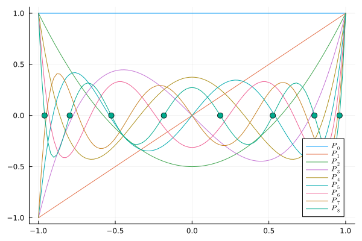

Next we approximate the integral

$$\begin{align}
\int_{-1}^{+1} \frac{1}{1 + e^{10(x - 0.5)}} \mathrm{d}x
\end{align}$$

by using *(i)* the composite trapezoid rule, *(ii)* the composite Simpson rule (from last time) and *(iii)* Gaussian quadrature.

What rates of convergence do you expect to see?

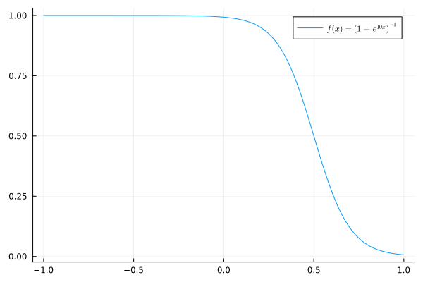

```julia
a, b = -1, 1
f = x -> 1/( 1 + exp( 10*(x-.5) ))
df_max = 5/2
d2f_max = 50/(3*sqrt(3))
d3f_max = 125/3

exact = (5 + log( 1 - exp(5) + exp(10) ) ) / 10

plot(f, a, b, label=L"f(x) = (1 + e^{10x})^{-1}")
```

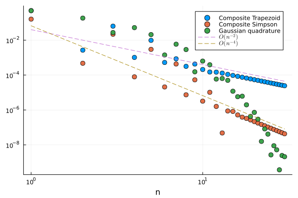

```julia
N = 30
T = []  # Composite trapezoid rule
S = []  # Simpson
G = []  # Gaussian rule

for n ∈ 1:N
    h = (b-a)/n
    x = [a + j*(b-a)/n for j in 0:n]
    push!( T, sum( [ (1/2)*( x[j+1] - x[j] ) * ( f(x[j]) + f(x[j+1]) ) for j in 1:n] ) )

    h = (b-a)/(2*n)
    y = [a + j*(b-a)/(2*n) for j in 0:(2*n)]

    p = 0
    for j in 0:2*n
        if j==0
            p = p + f( y[j+1] )
        elseif j==2*n
            p = p + f( y[j+1] )
        elseif mod(j,2)==0
            p = p + 2*f( y[j+1] )
        else
            p = p + 4*f( y[j+1] )
        end
    end
    push!( S, h*p/3 )

    r = roots( Legendre(n) )
    p = fit( r, f.(r) )
    I = integrate( p )
    push!( G, I(1) - I(-1) )

end

scatter( abs.(T .- exact ), xlabel=L"n", xaxis=:log, yaxis=:log, markersize=5, label="Composite Trapezoid" )
scatter!( abs.(S .- exact), markersize=5, label="Composite Simpson")
scatter!( abs.(G .- exact ), markersize=5, label="Gaussian quadrature" )

#plot!( (1/12)*d2f_max*(b-a)^3*(1:N).^(-2), linestyle=:dash, label="error bound (Trapezoid)" )
plot!( (1/25)*(1:N).^(-2), linestyle=:dash, label=L"O(n^{-2})" )
#plot!( (1/(27))*d3f_max*(b-a)^4*(1:N).^(-3), linestyle=:dash, color=:red, label="error bound (Simpson)" )
plot!( (1/15)*(1:N).^(-4), linestyle=:dash, label=L"O(n^{-4})" )
# plot!( (1/2880)*d4f_max*(b-a)^5*(1:N).^(-4), linestyle=:dash, label="n^{-4}" )
```

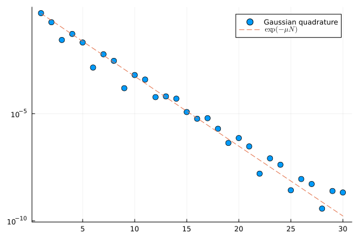

```julia
scatter( abs.(G .- exact ), yaxis=:log, markersize=5, label="Gaussian quadrature" )
plot!( exp.(-(1:N)* 3/4 ), linestyle=:dash, label=L"\exp( - μ N )" )
```

One way to see exponential convergence comes from the following error estimate. Let $(w_j, x_j)_{j=0}^{n+1}$ be the weights and nodes from Gaussian quadrature and let $I_Xf$ be the polynomial interpolation of $f$ on $X = \{x_j\}_{j=0}^n$. Then, because $\int_{-1}^{+1} P_{2n+1} = \sum_{j=0}^n w_j P_{2n+1}$ for all polynomials $P_{2n+1}$ of degree $2n+1$, we have
$$\begin{align}
&\Big|\int_{-1}^{+1} f(x) \mathrm{d}x - \sum_{j=0}^n w_j f(x_j)\Big| \nonumber\\
%
&\leq \Big|\int_{-1}^{+1} \left( f(x) - P_{2n+1}(x) \right) \mathrm{d}x\Big|
%
+ \Big|\sum_{j=0}^n w_j \left( f(x_j) - P_{2n+1}(x_j) \right) \Big| \nonumber\\
%
&\leq 4 \max_{x\in [-1,1]}| f(x) - P_{2n+1}(x) | =: 4 \|f-P_{2n+1}\|_{L^\infty}.
\end{align}$$
Here, we have used the fact that $|\int_{-1}^{+1} g| \leq 2 \|g\|_{L^\infty}$ and $|\sum_{j=0}^n w_j g(x_j)| \leq \sum_{j=0}^n |w_j| |g(x_j)| \leq 2 \|g\|_{L^\infty}$ (because the weights are positive and sum to $2$). We obtain the error estimates as seen in the plot above by showing that polynomial approximations to $f(x) = (1 + e^{10(x-\tfrac12)})^{-1}$ on $[-1,1]$ converge exponentially as $n\to\infty$; a possible presentation topic. (We may also return to this in Chapter 6: Approximation theory, time permitting).

## 12.4 How to compute the roots of $P_{n+1}$?

Recall, $P_0(x) = 1, P_1(x) = x$, and

$$\begin{align}
xP_n(x) = a_n P_n(x) + P_{n+1}(x) + b_n P_{n-1}(x).
\end{align}$$

It turns out that $X = \{ \text{zeros of } P_{n+1} \}$ is the set of eigenvalues of a tridiagonal matrix $T$ (see: Assignment 7). Next chapter, we will see methods for finding the eigenvalues of this matrix!

## 12.5 Next time….

- Chapter 5: Linear systems of equations,
- Motivation: where linear systems come from (polynomial interpolation, differential equations),
- Cramer’s rule, Gaussian elimination and the LU decomposition,
- Reading: Section 6.1 of Burden et al. (2016).

**TipTO-DO**

- Exercises throughout the notes,
- Choose a presentation topic,
- Extra reading: [myths of polynomial interpolation](https://people.maths.ox.ac.uk/trefethen/mythspaper.pdf)
- (Sign-up to office hours if you like)

## 12.6 Extra exercises

**Exercise 12.7**

Show that the two definitions in Definition 12.2 are equivalent.

**Exercise 12.8**

Show that Gauss quadrature with nodes $X = \{x_0, \dots, x_n\}$ is **never** exact for all polynomials of degree $N > 2n+1$.

**Exercise 12.9**

1. Write down the Gaussian quadrature rule with $n=2$.
2. What is the absolute error in approximating $\log 2$ using the $n=2$ scheme and following the same arguments as in class (see Exercise 12.4)?
3. How would you prove an error bound for the $n=2$ rule in general?

**Exercise 12.10**

Show that the roots of $P_{n+1}$ are real, distinct, and lie in the open interval $(-1,1)$ (compare with the proof of Lemma 12.1).

Burden, Richard L., J. Douglas Faires, and Annette M. Burden. 2016. *Numerical Analysis*. 10th ed. Cengage Learning. https://doi.org/10.13140/2.1.4830.2406.

Timer

00:00

min